# Table of Contents

#### ProdTaken vs OwnCar

```
ProdTaken     0    1   All
OwnCar
All        3968  920  4888
1          2472  560  3032
0          1496  360  1856
----------------------------------------------------------------------------------------------------
```

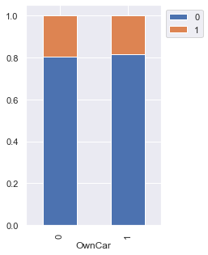

```python
stacked_barplot(df, "OwnCar", "ProdTaken")
```

- Approx 20% percentage of customers who do NOT own a car purchase a travel package compared to 18% of customers who own one.

#### ProdTaken vs PitchSatisfactionScore

```
ProdTaken                  0    1   All
PitchSatisfactionScore
All                     3968  920  4888
3                       1162  316  1478
5                        760  210   970
4                        750  162   912
1                        798  144   942
2                        498   88   586
----------------------------------------------------------------------------------------------------
```

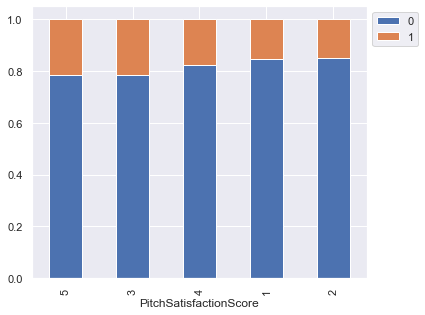

```python
stacked_barplot(df, "PitchSatisfactionScore", "ProdTaken")
```

#### ProdTaken vs NumberOfFollowups

```
ProdTaken             0    1   All
NumberOfFollowups
All                3931  912  4843
4.0                1689  379  2068
3.0                1222  244  1466
5.0                 577  191   768
6.0                  82   54   136
2.0                 205   24   229
1.0                 156   20   176
----------------------------------------------------------------------------------------------------
```

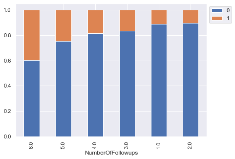

```python
stacked_barplot(df, "NumberOfFollowups", "ProdTaken")
```

- Higher the number of follow ups, higher the probability of purchasing a travel package

#### Checking if Designation and Monthly Income are related

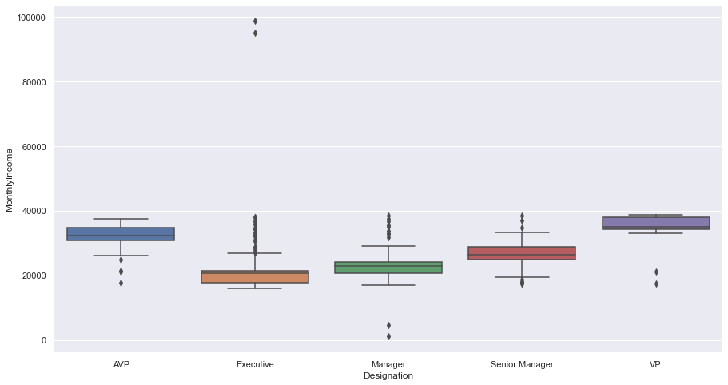

```python
plt.figure(figsize=(15, 8))
sns.boxplot(df["Designation"], df["MonthlyIncome"])
plt.show()
```

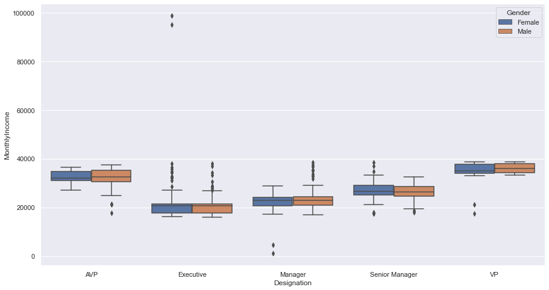

```python
plt.figure(figsize=(15, 8))
sns.boxplot(df["Designation"], df["MonthlyIncome"], hue=df["Gender"])
plt.show()
```

- As the designation increases, we see that the Monthly Salary also increases. Monthly Salary is a function of Designation.
- We see that women are paid equally to men at all the designations

#### Checking if Occupation and Monthly Income are related

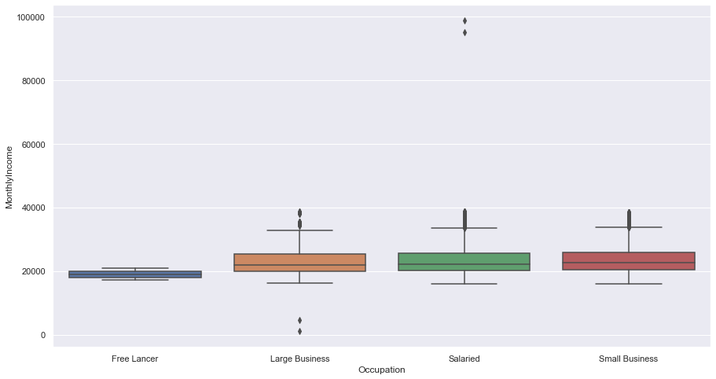

```python
plt.figure(figsize=(15, 8))
sns.boxplot(df["Occupation"], df["MonthlyIncome"])
plt.show()
```

- Free Lancers earn less than customers employed in Salaried, Small or Large business

#### Checking if Designation and NumberOfTrips are related

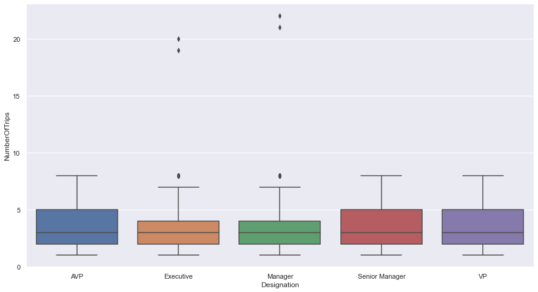

```python
plt.figure(figsize=(15, 8))
sns.boxplot(df["Designation"], df["NumberOfTrips"])
plt.show()
```

#### Checking if Designation and Age are related

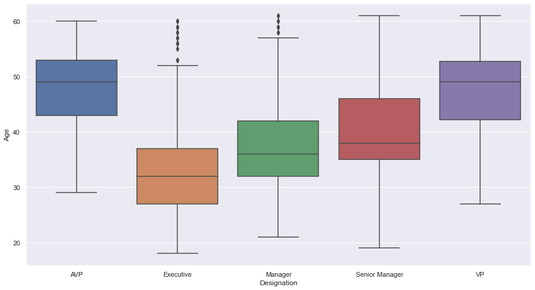

```python
plt.figure(figsize=(15, 8))
sns.boxplot(df["Designation"], df["Age"])
plt.show()
```

- People in higher designations are older than the people in lower designations